Gobierno Autónomo Descentralizado Municipal del Cantón Loja · Universidad Nacional de Loja

Carrera de Economía · Dirección Técnica de Arquitectura Sostenible

# Delimitación Periurbana del Corredor Sur de Loja

Criterios catastrales, zonificación PUGS, encaje censal CPV 2022 y mitigación de limitaciones metodológicas.

### Equipo Formulador · Carrera de Economía, UNL

Erick Fabricio Condoy Seraquive · Amanda Salomé Gálvez Macas · Erick Sebastián Barba Sisalima

### Dirección Técnica · Carrera de Arquitectura Sostenible, UNL

Arq. Alexandra Aguilera Maldonado · Arq. Pablo Ernesto Bustos Peñarreta · Loja, noviembre de 2026

01 · Marco Territorial

## Problema Cartográfico y Principios Rectores

### Realidad institucional del suelo periurbano

El catastro barrial municipal y el amanzanamiento del INEC cubren únicamente la ciudad consolidada. En el corredor sur, la unidad censal mínima es el sector censal disperso, cuya extensión varía entre 296.71 hectáreas y 1,482.28 hectáreas, mezclando barrios habitados, fincas productivas y cordilleras vacías.

### Riesgo de usar polígonos aproximados

Rellenar sectores censales a ciegas con líneas rectas parte fincas privadas por la mitad, absorbe bosques intangibles y predios universitarios como si fuesen tejido residencial y distorsiona los indicadores de densidad.

### Objetivo técnico acordado

Delimitar nueve barrios periurbanos de un solo cuerpo con fronteras físicas y catastrales verificables, manteniendo trazabilidad del 100 por ciento hacia los seis sectores censales del CPV 2022.

1

### Integridad predial

Cada finca del catastro rural se asigna íntegra a un único barrio, evitando partir propiedades privadas por la mitad.

2

### Separación funcional del suelo

El equipamiento universitario de la UNL y el Área Intangible del PUGS sin viviendas quedan fuera del perímetro barrial residencial.

3

### Continuidad topológica

Fronteras compartidas con cero metros cuadrados de solapamiento y sin tierras de nadie entre barrios, universidad y áreas de conservación.

4

### Ponderación dasimétrica por edificaciones

Las variables censales se asignan según la ubicación real de techos habitados y no por superficie bruta.

02 · Insumos Base · WGS 84 UTM Zona 17 Sur

## Fuentes Oficiales y Cobertura Catastral

### Catastro Predial Rural y Urbano · GAD Loja

4,636 predios rurales, 3,607 predios urbanos y 2,342 huellas de construcción rural. Cubren entre el 95.0 por ciento y el 98.9 por ciento de siete de los nueve barrios periurbanos.

### Plan de Uso y Gestión del Suelo · PUGS Loja

328 polígonos de intervención rural, 39 urbanos, 102.73 kilómetros de red vial, 74.54 kilómetros de red hídrica, 2,965 medidores eléctricos, 1,285 polígonos de amenazas y 15,956 de pendientes.

### Cartografía y Microdatos CPV 2022 · INEC

Seis sectores censales dispersos del corredor sur, manzanas urbanas recortadas a El Capulí y edificaciones residenciales físicas verificadas.

### Predios Institucionales · UNL

Campus La Argelia de 79.37 hectáreas, Parque Universitario de 100.20 hectáreas y Estación Punzara de 65.81 hectáreas, todos preservados como unidades propias.

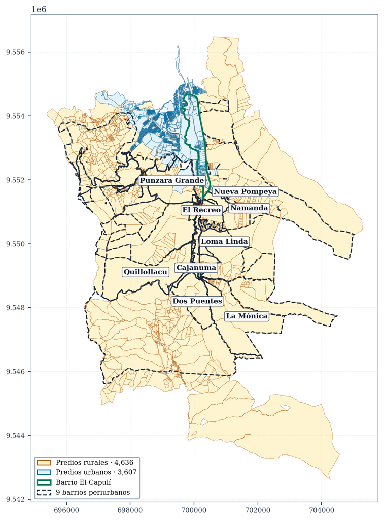

03 · Regla de Delimitación

## Criterios de Delimitación y Asignación Predial

1

### Cuerpo único por comunidad barrial

Se disolvieron las particiones norte, sur, núcleo y disperso de la versión preliminar para obtener nueve barrios íntegros y legibles: Ñamanda, El Recreo, Loma Linda, Nueva Pompeya, Quillollacu, Punzara Grande, Dos Puentes, La Mónica y Cajanuma.

2

### Exclusión estricta de la UNL

Se sustrajeron 112.50 hectáreas universitarias sin viviendas que antes caían en Punzara Grande y Nueva Pompeya: 62.98 hectáreas del Parque Universitario, 24.62 hectáreas de la Estación Punzara y 24.90 hectáreas adicionales del Parque Universitario.

3

### Integridad predial indivisible · 1,063 predios

Como el catastro rural no trae código de barrio, cada finca se evaluó como unidad indivisible sobre el ámbito de influencia de viviendas, localidades y centralidades PUGS. Si contiene viviendas del barrio o la mayoría de su superficie pertenece a ese ámbito, el predio completo entra íntegro al barrio.

4

### Filtro ambiental PUGS de tres condiciones

Todo predio rural mayor a 10 hectáreas, con 0 viviendas censales, 0 construcciones rurales y más del 80 por ciento de su superficie en Área Intangible PUGS se excluye del barrio y pasa a la capa contigua de protección ecológica de 1,260.99 hectáreas.

04 · Barreras Físicas y Normativa PUGS

## Zonificación PUGS, Red Vial y Red Hídrica

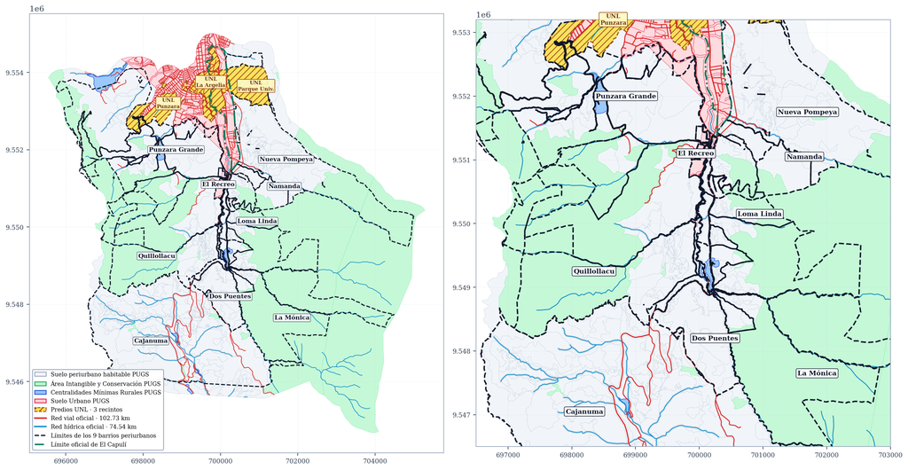

### Valle habitable

Producción agropecuaria mixta y agrosilvopastoril a lo largo del eje vial sur concentra el tejido habitado.

### Borde de transición

Áreas de convivencia sustentable y centralidades mínimas rurales marcan los núcleos consolidados.

### Límite exterior natural

Las cordilleras de Área Intangible sin casas delimitan el tope superior oriental y occidental.

### Soporte de infraestructura

102.73 kilómetros de vías y 74.54 kilómetros de red hídrica respaldan los cortes entre barrios.

05 · Ajustes Espaciales

## Depuración de Fronteras y Cierre de El Capulí

### Margen oriental de El Capulí

Nueva Pompeya absorbió la franja libre entre el borde este de El Capulí y el Parque Universitario, cerrando la frontera derecha con cero solapamiento frente a los nueve sectores internos de El Capulí.

### Margen occidental · Barrio La Argelia

El límite occidental de El Capulí colinda con el Barrio La Argelia de 205.66 hectáreas. Al descontar los predios de la UNL, su sector contiguo al corredor sur queda en 117.58 hectáreas.

### El Capulí oficial frente a El Capulí neto

Se conserva el polígono oficial de 115.12 hectáreas como referencia normativa y se reportan sus métricas netas sin suelo universitario sobre 66.28 hectáreas, excluyendo 48.84 hectáreas de Campus La Argelia y Parque Universitario con 258 viviendas y 878.0 habitantes estimados.

### Alineación a fronteras censales del corredor sur

La Mónica se ajustó al borde norte del Sector Censal 5, devolviendo 101.02 hectáreas sin casas a Nueva Pompeya y Ñamanda en el Sector Censal 6.

### Unificación de Cajanuma y Dos Puentes

Cajanuma cedió 173.95 hectáreas vacías en el Sector Censal 3 a Quillollacu y quedó íntegramente en el Sector Censal 4. Su frontera con Dos Puentes se reteseló eliminando la cuña triangular y el apéndice de 16.34 hectáreas.

06 · Cartografía Definitiva

## Delimitación Final de los Nueve Barrios Periurbanos

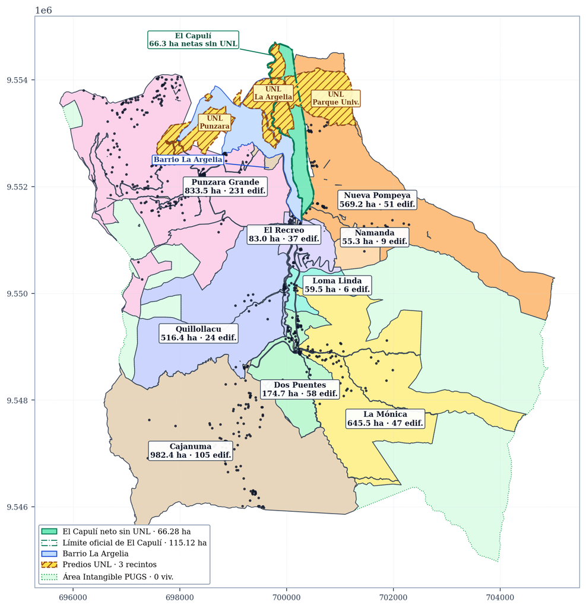

3,919.57 ha

Superficie habitable y productiva de los 9 barrios periurbanos

1,260.99 ha

Área Intangible PUGS separada en capa contigua con 0 viviendas

1,063 predios

Predios rurales asignados completos sin fraccionar propiedades

0.00 m² · 0 viv.

Cero solapamientos topológicos y cero viviendas censales perdidas

07 · Balance Territorial y Demográfico

## Resultados Consolidados por Barrio

[output not shown]

08 · Conciliación Censal CPV 2022

## Encaje Censal y Ponderación Dasimétrica

### Ponderación por edificaciones residenciales

En lugar de repartir población por superficie bruta, cada intersección entre barrio y sector censal recibe un peso igual a su proporción de edificaciones físicas:

w<sub>b,s</sub> = n<sub>b,s</sub> / N<sub>s</sub> · Ŷ<sub>b</sub> = Σ w<sub>b,s</sub> · Y<sub>s</sub>

| Sector censal | Subpolígonos | Área barrios ha | Edif. asig. | Edif. INEC | Suma w |
| --- | --- | --- | --- | --- | --- |
| Sector Censal 1 | 2 | 435.57 | 128 | 128 | 1.0000 |
| Sector Censal 2 | 3 | 208.73 | 91 | 91 | 1.0000 |
| Sector Censal 3 | 4 | 742.68 | 46 | 46 | 1.0001 |
| Sector Censal 4 | 4 | 1,090.57 | 116 | 116 | 0.9999 |
| Sector Censal 5 | 4 | 699.10 | 95 | 93 | 1.0215 |
| Sector Censal 6 | 6 | 725.43 | 75 | 85 | 0.8824 |
| Sectores urbanos | 2 | 17.49 | 17 | --- | 0.1319 |

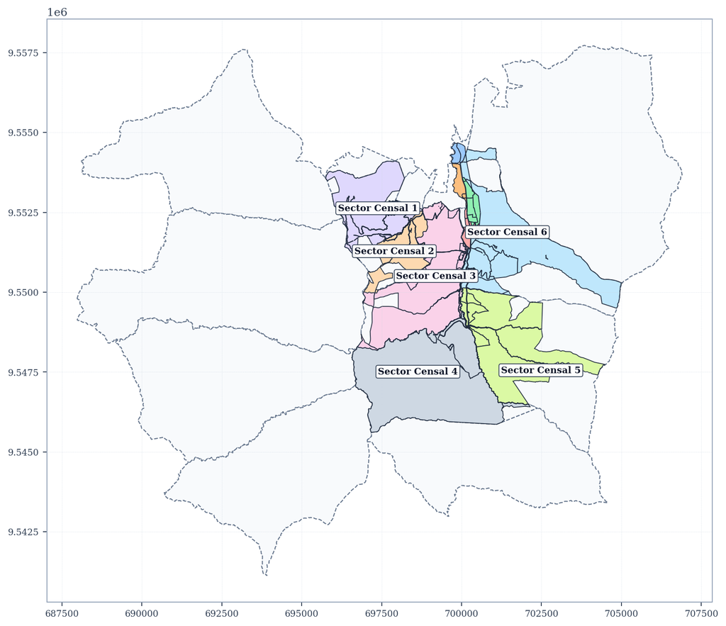

09 · Criterio, Respaldo y Validez

## Justificación, Respaldo y Sensibilidad de Umbrales

[output not shown]

### Composición del Área Intangible contigua · 1,260.99 hectáreas

El 99.8 por ciento coincide con la categoría Área Intangible PUGS: 320.90 hectáreas corresponden a 12 predios rurales deshabitados y 940.09 hectáreas a cordillera alta no catastrada, todas con cero viviendas y cero construcciones.

10 · Rigor Metodológico

## Limitaciones Metodológicas y Mitigaciones

| Limitación metodológica | Riesgo territorial o estadístico | Mitigación aplicada en el levantamiento |
| --- | --- | --- |
| **1. Catastro rural sin código de barrio** | Ningún registro municipal asigna de origen a qué barrio pertenece cada finca rural. | Regla determinística de pertenencia por viviendas censales, localidades y mayoría espacial, asignando los 1,063 predios como unidades indivisibles. |
| **2. Fincas limítrofes despobladas y corte parroquial** | En fronteras sin viviendas la adscripción puede diferir, y 17 fincas en el sur de Cajanuma cruzan el límite parroquial excluyendo 34.15 hectáreas externas sin viviendas. | Reasignación íntegra predio a predio en fronteras internas y mantenimiento del corte parroquial, pasando la densidad bruta de Cajanuma de 0.260 a 0.269 hab/ha sin alterar conteos censales. |
| **3. Barrios que cruzan sectores censales** | Imposibilidad de sumar sectores censales completos sin mezclar población de barrios vecinos. | Cruce de intersección exacta con ponderación dasimétrica por edificaciones residenciales en lugar de área bruta. |
| **4. Montañas vacías y suelo universitario** | Subestimación artificial de densidad al incluir cordilleras protegidas y recintos de la UNL en los barrios. | Exclusión íntegra de 112.50 hectáreas universitarias y separación contigua de 1,260.99 hectáreas de Área Intangible PUGS con 0 viviendas. |
| **5. Crecimiento posterior al Censo 2022** | Viviendas construidas entre 2023 y 2026 pueden no constar aún en los puntos censales base. | Cruce complementario con 2,342 huellas de construcciones rurales, 2,965 medidores eléctricos activos y verificación directa durante el barrido de encuestas. |

01 / 10